# Causes for Delays and cancellation of Flights in the US

## by Mahmoud Elsayed

## Investigation Overview

> The main goal of this presentation is to investigate the main reasons for delays and cancellations of flights, First thing comes to mind that the weather is the main effect that causes delays of flights, however. this presentation will show that this isn't true and will show other surprising insights and findings.

## Dataset Overview

> The dataset contains 294237 flight observations focused on delays factors like carrier, weather, nas, security,... from june 2003 to january 2021

## (Worst state with respect to weather)

> First lets look at the states and see which state has the highest delayed flight because of its weather Texas has the highest weather caused delayed flights

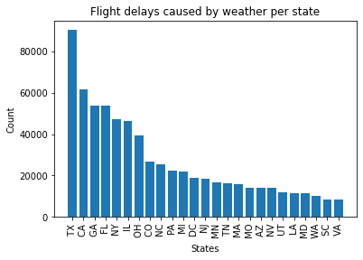

## (Delayed flights Causes per year)

> This Graphs clearly shows the different delays causes and the count of delayed flights per year and to my surprise Weather isn't the main cause for delays not even the second most.However, late_aircrafts are the main reasons for flight delays, while the weakest cause for delays is security reasons.

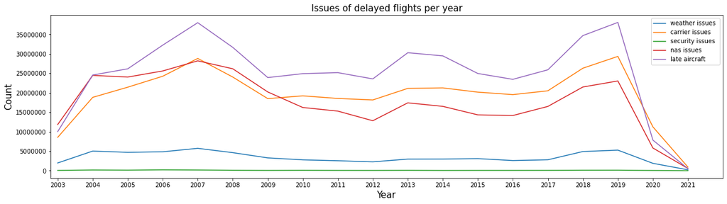

> Another unintuitive insight that the most delayed flights aren't in the cold rainy weather but infact in the hot months of the year as shown in the graph the peak of the curve is at june and july months.

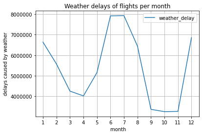